# EP06-Estadistica

Equipo 1

06-05-2026

## Información General

Un equipo de investigadores del área de interacción humano-información está estudiando si el área temática y el nivel de dificultad del problema de información influyen en el tiempo (en segundos) que toma un usuario en formular una consulta de búsqueda para resolver dicho problema. Para ello, han reclutado a un grupo de participantes voluntarios, asignados aleatoriamente a distintos grupos. Cada participante debe resolver tres problemas de información con diferentes niveles de dificultad: baja, media y alta. A su vez, cada grupo debe resolver problemas relacionados a una temática diferente. Los datos recolectados contemplan las siguientes variables:

[output not shown]

# Problema 1

En este momento, los investigadores buscan determinar si existen diferencias en el tiempo que tardan los usuarios en formular consultas para problemas con diferente nivel de dificultad en el área de física.

# Respuesta 1

Para determinar si existen diferencias significativas en el tiempo promedio que tardan los usuarios en formular consultas según el nivel de dificultad en el área de física, se haría un procedimiento ANOVA de una vía para muestras correlacionadas (también conocido como ANOVA de medidas repetidas).

Dado que los mismos participantes realizan problemas en los tres niveles de dificultad, las mediciones entre niveles están correlacionadas dentro de cada sujeto. Por eso corresponde usar ANOVA para muestras correlacionadas. Sin embargo, se asume independencia entre participantes, ya que el desempeño de un usuario no debería influir en el desempeño de otro.

Se cargan los datos, se filtra el área de Física y se realiza una exploración descriptiva inicial del tiempo de formulación de consultas según nivel de dificultad.

```r
library(tidyverse)
library(ez)

datos <- read.csv("EP06 Datos.csv", sep = ",", dec = ",")

datos_fisica <- datos %>%
  filter(area == "Física") %>%
  mutate(dificultad = factor(dificultad, levels = c("Baja", "Media", "Alta")))

glimpse(datos_fisica)
```

```
## Rows: 600
## Columns: 4
## $ id         <int> 8, 8, 8, 31, 31, 31, 32, 32, 32, 33, 33, 33, 44, 44, 44, 46…
## $ area       <chr> "Física", "Física", "Física", "Física", "Física", "Física",…
## $ dificultad <fct> Baja, Media, Alta, Baja, Media, Alta, Baja, Media, Alta, Ba…
## $ tiempo     <int> 93, 100, 106, 86, 76, 87, 94, 86, 102, 96, 84, 100, 89, 72,…
```

```r
sum(is.na(datos_fisica))
```

```
## [1] 0
```

```r
datos_fisica %>%
  group_by(dificultad) %>%
  summarise(
    n = n(),
    media = mean(tiempo, na.rm = TRUE),
    sd = sd(tiempo, na.rm = TRUE),
    mediana = median(tiempo, na.rm = TRUE),
    minimo = min(tiempo, na.rm = TRUE),
    maximo = max(tiempo, na.rm = TRUE),
    .groups = "drop"
  )
```

| dificultad | n | media | sd | mediana | minimo | maximo |
| --- | --- | --- | --- | --- | --- | --- |
| Baja | 200 | 87.12 | 7.626692 | 87 | 66 | 106 |
| Media | 200 | 86.94 | 7.427127 | 87 | 68 | 106 |
| Alta | 200 | 94.23 | 7.545980 | 94 | 76 | 114 |

Descriptivamente, los tiempos promedio de dificultad Baja y Media son muy similares, mientras que el nivel Alta presenta un promedio mayor. Esto sugiere inicialmente que las posibles diferencias podrían estar asociadas principalmente a la dificultad Alta.

## Formulación de Hipótesis

Para responder a la pregunta de investigación mediante el ANOVA de medidas repetidas, definimos las siguientes hipótesis:

- $H_0$: El tiempo promedio que tardan los usuarios en formular consultas es el mismo para los tres niveles de dificultad en el área de Física ($\mu_{Baja} = \mu_{Media} = \mu_{Alta}$).
- $H_A$: El tiempo promedio de formulación de consultas difiere significativamente para al menos un nivel de dificultad en el área de Física.

Antes de proceder con la ejecución de la prueba ómnibus, es fundamental verificar que los datos recolectados cumplen con los supuestos matemáticos que garantizan la validez de este procedimiento

## Condiciones procedimiento ANOVA para muestras correlacionadas:

- 1: La escala con que se mide la variable dependiente tiene las propiedades de una escala de intervalos iguales.
- 2: Las observaciones son independientes al interior de cada muestra.
- 3: Se puede suponer razonablemente que las poblaciones de origen siguen una distribución normal.
- 4: La matriz de varianzas-covarianzas es esférica. (Varianzas entre los diferentes niveles de medidas repetidas deben ser iguales).

## Verificación de condiciones

### 1. Escala de intervalos iguales

Se cumple esta condición de manera teórica. La variable dependiente del estudio es el tiempo que tardan los usuarios en formular la consulta, medido en segundos. El tiempo es una variable continua medida en una escala de razón (la cual posee las propiedades de una escala de intervalos iguales), dado que la magnitud de la diferencia entre cualquier par de valores consecutivos (ej. un segundo) es matemáticamente constante en toda la escala.

### 2. Independencia al interior de cada muestra:

El enunciado indica que los investigadores reclutaron a un grupo de participantes voluntarios que fueron asignados aleatoriamente a distintos grupos. Dado que cada usuario resuelve los problemas de manera individual, se puede asumir que el tiempo de respuesta de un participante no influye en el tiempo de otro. Por lo tanto, las observaciones dentro de cada nivel de dificultad son independientes entre sí.

### 3. Normalidad de las poblaciones de origen

Esta condición requiere que nuestra variable dependiente, el tiempo de respuesta, siga una distribución aproximadamente normal para cada uno de los niveles (dificultad Baja, Media y Alta). Dado que la pregunta se centra en los usuarios que resolvieron problemas del área de Física, se filtró la muestra y se aplicará la prueba de Shapiro-Wilk para cada nivel de dificultad de manera independiente:

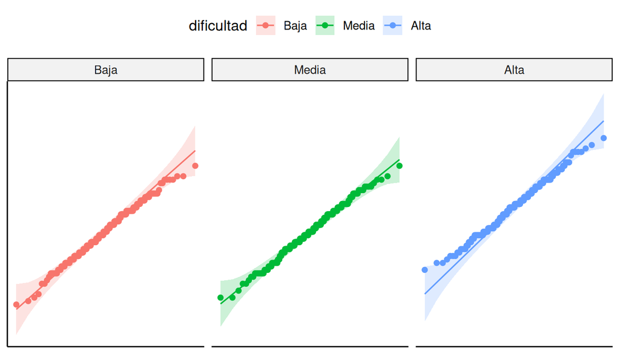

```r
ggqqplot(datos_fisica, x="tiempo", y="dificultad", color="dificultad", alpha=0.7) +
  facet_wrap(~dificultad) + rremove("x.ticks") + rremove("x.text") + rremove("y.ticks") + rremove("y.text") + rremove("axis.title")
```

En los gráficos Q-Q, los puntos se ubican aproximadamente alrededor de la línea teórica en los tres niveles de dificultad. Esto sugiere que el supuesto de normalidad es razonable.

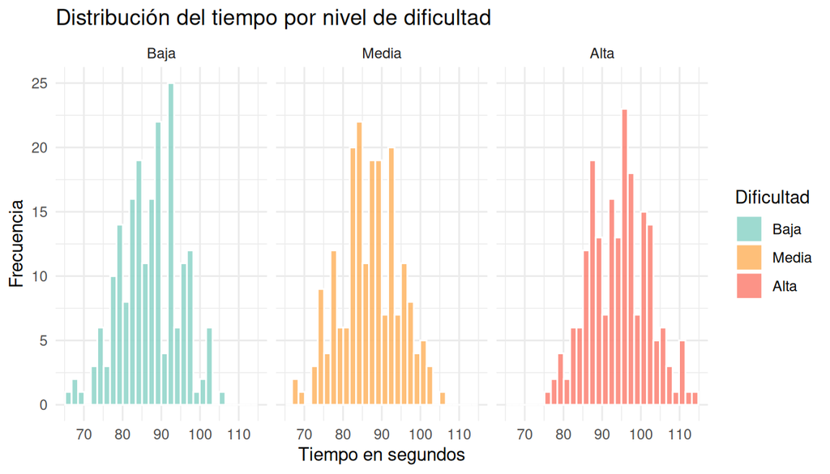

```r
# Agrupar los datos
datos_agrupados <- group_by(datos_fisica, dificultad)


ggplot(datos_fisica, aes(x = tiempo, fill = dificultad)) +
  geom_histogram(bins = 30, color = "white", alpha = 0.85) +
  facet_wrap(~ dificultad) +
  scale_fill_manual(values = c(
    "Baja" = "#8DD3C7",
    "Media" = "#FDB462",
    "Alta" = "#FB8072"
  )) +
  labs(
    title = "Distribución del tiempo por nivel de dificultad",
    x = "Tiempo en segundos",
    y = "Frecuencia",
    fill = "Dificultad"
  ) +
  theme_minimal()
```

Los histogramas muestran distribuciones aproximadamente simétricas, sin valores atípicos extremos evidentes. Esto es consistente con una distribución cercana a la normal.

```r
normalidad_fisica <- summarise(datos_agrupados,
                               p_valor = shapiro.test(tiempo)$p.value)

# Mostrar resultados
print("Resultados de la prueba de Shapiro-Wilk:")
```

```
## [1] "Resultados de la prueba de Shapiro-Wilk:"
```

```r
print(normalidad_fisica)
```

```
## # A tibble: 3 × 2
##   dificultad p_valor
##   <fct>        <dbl>
## 1 Baja         0.553
## 2 Media        0.596
## 3 Alta         0.484
```

Al observar los resultados de la prueba de Shapiro-Wilk, se aprecia que todos los p-valores son mayores a 0,05. Por lo tanto, no se rechaza la hipótesis nula de normalidad y se considera que este supuesto se cumple razonablemente.

### 4. Esfericidad de la matriz de varianza-covarianza

Esta condición es exclusiva de los diseños de medidas repetidas y establece que las varianzas de las diferencias entre todos los pares de niveles del factor deben ser iguales. Para verificar este supuesto, se utilizaría la Prueba de Mauchly.

```r
#1. Cargar librerías para ANOVA de medidas repetidas
library(ez)

#2. Ejecutar ANOVA ómnibus
# dv: variable dependiente (tiempo)
# wid: identificador del sujeto (id)
# within: factor intra-sujetos (dificultad)
# return_aov: para obtener el objeto aov si es necesario
prueba_anova <- ezANOVA(data = datos_fisica, dv = tiempo, wid = id, within = dificultad, return_aov = TRUE)

#3. Mostrar los resultados de la prueba de esfericidad de Mauchly
print("--- Prueba de Esfericidad de Mauchly ---")
```

```
## [1] "--- Prueba de Esfericidad de Mauchly ---"
```

```r
print(prueba_anova)
```

```
## $ANOVA
##       Effect DFn DFd        F            p p<.05       ges
## 2 dificultad   2 398 70.71079 5.284426e-27     * 0.1694951
##
## $`Mauchly's Test for Sphericity`
##       Effect         W        p p<.05
## 2 dificultad 0.9990732 0.912293
##
## $`Sphericity Corrections`
##       Effect       GGe       p[GG] p[GG]<.05      HFe        p[HF] p[HF]<.05
## 2 dificultad 0.9990741 5.56544e-27         * 1.009203 5.284426e-27         *
##
## $aov
##
## Call:
## aov(formula = formula(aov_formula), data = data)
##
## Grand Mean: 89.43
##
## Stratum 1: id
##
## Terms:
##                 Residuals
## Sum of Squares   14422.39
## Deg. of Freedom       199
##
## Residual standard error: 8.513186
##
## Stratum 2: id:dificultad
##
## Terms:
##                 dificultad Residuals
## Sum of Squares     6915.24  19461.43
## Deg. of Freedom          2       398
##
## Residual standard error: 6.992715
## Estimated effects may be unbalanced
```

```r
# 4. Mostrar los resultados del ANOVA (incluye correcciones si falló Mauchly)
print("--- Resultados del ANOVA Ómnibus ---")
```

```
## [1] "--- Resultados del ANOVA Ómnibus ---"
```

```r
print(prueba_anova$ANOVA)
```

```
##       Effect DFn DFd        F            p p<.05       ges
## 2 dificultad   2 398 70.71079 5.284426e-27     * 0.1694951
```

Al ejecutar el procedimiento en R, se obtuvo un valor estadístico $W = 0,999$ con un p-valor de $0,912$. Dado que el p-valor es considerablemente superior al nivel de significación $\alpha = 0,05$, no se rechaza la hipótesis nula de esfericidad. Por lo tanto, se concluye que los datos cumplen con el supuesto de esfericidad y no es necesario aplicar correcciones (como Greenhouse-Geisser) a los grados de libertad del ANOVA.

Una vez validados todos los supuestos, procedemos a interpretar los resultados de la prueba ANOVA Ómnibus generada en el paso anterior.

Observando la tabla de resultados ANOVA, el estadístico de prueba es $F(2, 398) = 70,71$ con un valor p minúsculo (casi 0). Adicionalmente, el tamaño del efecto generalizado ($\eta^2_G$) es de $0,169$, lo que indica que el nivel de dificultad explica aproximadamente el 16,9% de la varianza en los tiempos de respuesta.

Dado que el valor p es considerablemente menor al nivel de significación $\alpha = 0,05$, **se rechaza la hipótesis nula** ($H_0$). En consecuencia, existe evidencia estadísticamente significativa para afirmar que el tiempo promedio de formulación de consultas en el área de Física es diferente para al menos uno de los niveles de dificultad.

## Análisis Post-hoc

Debido a que la prueba ómnibus resultó significativa, es necesario aplicar un análisis post-hoc para identificar específicamente entre qué niveles de dificultad existen estas diferencias. Para un diseño de medidas repetidas, utilizaremos pruebas T de Student para muestras pareadas, aplicando el ajuste de Holm para controlar la tasa de falsos positivos (error de Tipo I) en comparaciones múltiples.

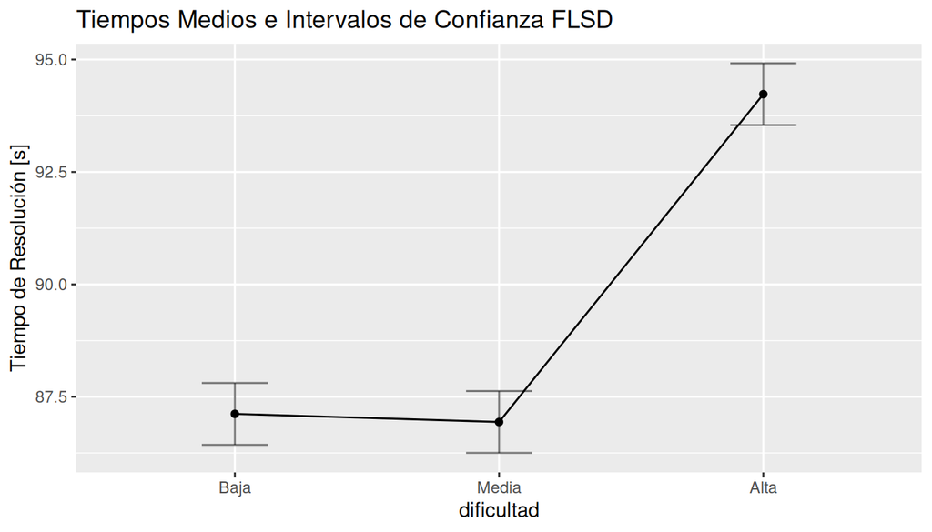

```r
ezPlot(data = datos_fisica, dv = tiempo, wid = id, within = dificultad,
       y_lab = "Tiempo de Resolución [s]", x = dificultad) +
  ggtitle("Tiempos Medios e Intervalos de Confianza FLSD")
```

En primer lugar, con la ayuda de ezPlot, podemos ver como existe una diferencia importante entre los tiempos de resolución de la dificultad baja y alta, y media y alta. Pero no se aprecian diferencias significativas entre la dificultad baja y media, para confirmar esto numéricamente procedemos al análisis de pruebas t pareadas con la correción de holm.

```r
holm <- pairwise.t.test(datos_fisica[["tiempo"]], datos_fisica[["dificultad"]],
                        p.adj= "holm", paired=TRUE, conf.level=1-0.05)
print(holm)
```

```
##
##  Pairwise comparisons using paired t tests
##
## data:  datos_fisica[["tiempo"]] and datos_fisica[["dificultad"]]
##
##       Baja   Media
## Media 0.8    -
## Alta  <2e-16 <2e-16
##
## P value adjustment method: holm
```

## Respuesta a la pregunta planteada

Al realizar el procedimiento ANOVA de una vía para muestras correlacionadas, se determinó que existen diferencias estadísticamente significativas en el tiempo que tardan los usuarios en formular consultas según el nivel de dificultad de los problemas en el área de Física ($F(2, 398) = 70,71$; $p < 0,001$). Por lo tanto, se rechaza la hipótesis nula general del ANOVA, que planteaba que los tiempos promedio eran iguales para los tres niveles de dificultad.

Sin embargo, este resultado general solo indica que existe al menos una diferencia entre los niveles, pero no señala específicamente entre qué niveles ocurre. Por esta razón, se realizó un análisis post-hoc utilizando pruebas T de Student para muestras pareadas con corrección de Holm.

En las comparaciones post-hoc, se rechaza la hipótesis nula de igualdad para los siguientes pares:

- Existe una diferencia estadísticamente significativa en el tiempo de respuesta entre los problemas de dificultad **Alta y Baja** ($p_{adj} < 0,001$).
- Existe una diferencia estadísticamente significativa en el tiempo de respuesta entre los problemas de dificultad **Alta y Media** ($p_{adj} < 0,001$).

En cambio, para la comparación entre **Media y Baja**, no se encontró evidencia suficiente para rechazar la hipótesis nula de igualdad ($p_{adj} = 0,800$). Esto significa que, aunque el ANOVA general muestra que no todos los niveles tienen el mismo tiempo promedio, la diferencia se explica principalmente por el nivel de dificultad **Alta**, mientras que los tiempos promedio de **Baja** y **Media** son estadísticamente similares.

## Conclusión

El nivel de dificultad tiene un impacto significativo en el tiempo que tardan los usuarios en formular consultas en el área de Física. Específicamente, los problemas de dificultad Alta presentan tiempos promedio significativamente mayores que los de dificultad Baja y Media, mientras que entre estos dos últimos no se observan diferencias estadísticas relevantes en el desempeño de los participantes.

# Problema 2

Propongan una pregunta de investigación relacionada al impacto del lenguaje de programación inicial (con el que se aprendió a programar) que necesite ser analizado por medio de un procedimiento ANOVA para muestras correlacionadas con un factor que tenga entre 4 y 6 niveles. Luego invente una población para cada grupo con 5.000 datos, asegurando que cumpla las suposiciones de esta prueba.

# Respuesta 2

¿Influye el lenguaje de programación inicial (Python, C++, Java o Go) en el tiempo (en minutos) que tarda un estudiante en resolver un algoritmo de ordenamiento complejo (como heapSort) después de 1, 3, 6 y 12 meses de práctica?

3 opciones para generar datos:

```r
library(MASS)    # Necesaria para mvrnorm()
library(dplyr)   # Opcional, para manipulación final de datos
library(ggplot2) # Opcional, para visualización rápida

# --- 1. CONFIGURACIÓN GLOBAL ---
N_POR_GRUPO <- 5000  # Número de estudiantes por cada lenguaje
N_MESES <- 4         # Los 4 momentos de medición (1, 3, 6, 12)

# Definimos los nombres correctos para las columnas (las variables de tiempo)
NOMBRES_COLUMNAS_TIEMPO <- c("1 mes", "3 meses", "6 meses", "12 meses")

# --- 2. DEFINICIÓN DE LA ESTRUCTURA DE COVARIANZA (Constante para todos) ---
# Asumimos que la variabilidad y la correlación intrínseca de un estudiante
# es la misma, independientemente del lenguaje que use.

VARIANZA_CONSTANTE <- 25 # Varianza igual en todos los meses (desv. estándar = 5)
COVARIANZA_CONSTANTE <- 10 # Relación positiva entre mediciones del mismo sujeto

# Generamos la matriz base con la covarianza
sigma_global <- matrix(COVARIANZA_CONSTANTE, nrow=N_MESES, ncol=N_MESES)

# Reemplazamos la diagonal con la varianza
diag(sigma_global) <- VARIANZA_CONSTANTE

# Asignamos los nombres de los meses a las filas y columnas de la matriz
# (Esto hará que mvrnorm() asigne automáticamente estos nombres a las columnas de datos)
rownames(sigma_global) <- NOMBRES_COLUMNAS_TIEMPO
colnames(sigma_global) <- NOMBRES_COLUMNAS_TIEMPO


# --- 3. FUNCIÓN GENERADORA DE POBLACIONES ---
# Esta función toma las medias específicas de un lenguaje y genera sus datos.

generar_datos_lenguaje <- function(nombre_lenguaje, vector_medias) {

  # Generación de la matriz multivariada de tiempos
  tiempos_matriz <- mvrnorm(n = N_POR_GRUPO, mu = vector_medias, Sigma = sigma_global)

  # Convertimos la matriz en un 'data frame'
  datos_df <- as.data.frame(tiempos_matriz)

  # Añadimos una columna para identificar el factor "Lenguaje"
  datos_df$Lenguaje <- nombre_lenguaje

  # Aseguramos que la columna 'Lenguaje' sea un factor (importante para el ANOVA)
  datos_df$Lenguaje <- as.factor(datos_df$Lenguaje)

  return(datos_df)
}


# --- 4. DEFINICIÓN DE MEDIAS Y GENERACIÓN DE GRUPOS ---
# Aquí es donde simulamos el efecto de cada lenguaje.
# *Nota: He ajustado las medias para que simulen un "efecto de aprendizaje" lógico:
# los tiempos bajan conforme pasan los meses.*

# Grupo 1: Python (Simulamos un aprendizaje rápido y eficiente)
medias_python <- c(70, 60, 50, 45) # (1m, 3m, 6m, 12m)
datos_python <- generar_datos_lenguaje("Python", medias_python)

# Grupo 2: C++ (Simulamos una curva de aprendizaje inicial más difícil)
medias_cpp <- c(80, 65, 55, 48)
datos_cpp <- generar_datos_lenguaje("C++", medias_cpp)

# Grupo 3: Java (Simulamos un rendimiento intermedio)
medias_java <- c(75, 62, 53, 46)
datos_java <- generar_datos_lenguaje("Java", medias_java)

# Grupo 4: Go (Simulamos un rendimiento similar a Python pero con menos 'curva')
medias_go <- c(72, 61, 51, 46)
datos_go <- generar_datos_lenguaje("Go", medias_go)


# --- 5. UNIÓN DE TODAS LAS POBLACIONES (DATASET FINAL) ---
# Usamos rbind() para "pegar" una tabla debajo de la otra.

dataset_completo <- rbind(datos_python, datos_cpp, datos_java, datos_go)


# --- 6. VERIFICACIÓN DE RESULTADOS ---

# Ver la estructura del dataset final
str(dataset_completo)
```

```
## 'data.frame':    20000 obs. of  5 variables:
##  $ 1 mes   : num  70.8 74 74.2 71.8 66.6 ...
##  $ 3 meses : num  57.7 58.3 60.3 69 64.3 ...
##  $ 6 meses : num  45.1 53.8 49.4 57.4 55 ...
##  $ 12 meses: num  37.9 54.3 37.8 43.9 51.9 ...
##  $ Lenguaje: Factor w/ 4 levels "Python","C++",..: 1 1 1 1 1 1 1 1 1 1 ...
```

```r
# Debería mostrar 20,000 obs. y 5 variables (4 de tiempo + 1 factor Lenguaje)

# Ver las primeras filas
head(dataset_completo)
```

|  | 1 mes | 3 meses | 6 meses | 12 meses | Lenguaje |
| --- | --- | --- | --- | --- | --- |
| 1 | 70.75204 | 57.67945 | 45.11249 | 37.91956 | Python |
| 2 | 73.97151 | 58.28736 | 53.78946 | 54.29082 | Python |
| 3 | 74.21826 | 60.33611 | 49.36258 | 37.79172 | Python |
| 4 | 71.81364 | 68.97461 | 57.43039 | 43.91279 | Python |
| 5 | 66.56279 | 64.28705 | 55.04982 | 51.92613 | Python |
| 6 | 72.34922 | 69.46734 | 61.25760 | 53.30272 | Python |

```r
# Verás las columnas: "1 mes", "3 meses", "6 meses", "12 meses" y "Lenguaje"

# Ver resumen estadístico rápido por grupo (usando dplyr para comodidad)
# dataset_completo %>% group_by(Lenguaje) %>% summarize(
#   Media_1m = mean(`1 mes`),
#   Media_12m = mean(`12 meses`)
# )
```

```r
# =============================================================
# ENFOQUE 2: MODELO DE EFECTOS ALEATORIOS (Sujeto como Base)
# =============================================================

n <- 5000

generar_poblacion_sujetos <- function(nombre_lenguaje, medias_incremento) {

  # 1. Capacidad base del individuo (constante para el sujeto en el tiempo)
  # Usamos una media de 50 como punto de partida neutral
  sujetos_base <- rnorm(n, mean=50, sd=10)

  # 2. Generamos los niveles (meses) sumando el efecto del tiempo a la base
  # Cada nivel tiene su propia media de incremento y su error (sd=2)
  mes1  <- sujetos_base + rnorm(n, mean = medias_incremento[1], sd = 2)
  mes3  <- sujetos_base + rnorm(n, mean = medias_incremento[2], sd = 2)
  mes6  <- sujetos_base + rnorm(n, mean = medias_incremento[3], sd = 2)
  mes12 <- sujetos_base + rnorm(n, mean = medias_incremento[4], sd = 2)

  # 3. Creamos el data frame con los nombres que pediste
  df <- data.frame(
    "1 mes" = mes1,
    "3 meses" = mes3,
    "6 meses" = mes6,
    "12 meses" = mes12,
    Lenguaje = as.factor(nombre_lenguaje),
    check.names = FALSE # Permite espacios en los nombres de columnas
  )

  return(df)
}

# --- 3. GENERACIÓN DE CADA GRUPO ---
# Nota: Aquí las medias son "incrementos" sobre la base de 50.
# Si quieres que el total sea ~70, el incremento debe ser ~20.

datos_python <- generar_poblacion_sujetos("Python", c(20, 15, 10, 5))
datos_cpp    <- generar_poblacion_sujetos("C++",    c(30, 20, 15, 10))
datos_java   <- df_java <- generar_poblacion_sujetos("Java",   c(25, 18, 12, 8))
datos_go     <- generar_poblacion_sujetos("Go",     c(22, 16, 11, 7))

# --- 4. UNIÓN FINAL ---
dataset_final_sujetos <- rbind(datos_python, datos_cpp, datos_java, datos_go)

# Verificación
head(dataset_final_sujetos)
```

|  | 1 mes | 3 meses | 6 meses | 12 meses | Lenguaje |
| --- | --- | --- | --- | --- | --- |
| 1 | 47.83659 | 43.39641 | 39.16980 | 34.76566 | Python |
| 2 | 62.42338 | 54.12588 | 51.09463 | 46.95347 | Python |
| 3 | 85.17241 | 79.64421 | 75.77941 | 69.92718 | Python |
| 4 | 66.00525 | 65.81541 | 56.57214 | 49.75534 | Python |
| 5 | 69.45648 | 61.07803 | 63.23181 | 54.28009 | Python |
| 6 | 56.97345 | 51.42803 | 47.45996 | 40.99461 | Python |

```r
# =============================================================
# SIMULACIÓN COMPLETA: IMPACTO DEL LENGUAJE INICIAL (FORMATO LARGO)
# =============================================================

# Configuración de parámetros globales
n_sujetos_por_grupo <- 5000
meses_labels <- c("1 mes", "3 meses", "6 meses", "12 meses")
n_meses <- length(meses_labels)

# 1. FUNCIÓN GENERADORA DE DATOS (Basada en el Enfoque 3)
# -------------------------------------------------------------
generar_poblacion_larga <- function(nombre_lenguaje, efecto_aprendizaje) {

  # Crear la estructura de malla (ID x Mes)
  # Esto genera 20,000 filas por lenguaje (5,000 sujetos * 4 meses)
  df_grupo <- expand.grid(
    ID = 1:n_sujetos_por_grupo,
    Mes = factor(meses_labels, levels = meses_labels)
  )

  # Efecto de Sujeto: La "habilidad intrínseca" constante por individuo [cite: 63]
  sujeto_id_efecto <- rep(rnorm(n_sujetos_por_grupo, mean = 0, sd = 10), each = n_meses)

  # Efecto de Aprendizaje: La mejora (reducción de tiempo) promedio por mes [cite: 34]
  # Repetimos el vector de aprendizaje para cada uno de los 5,000 sujetos
  aprendizaje_efecto <- rep(efecto_aprendizaje, times = n_sujetos_por_grupo)

  # Error Aleatorio: El "ruido" específico de cada medición [cite: 64]
  error <- rnorm(nrow(df_grupo), mean = 0, sd = 5)

  # Variable Dependiente (Tiempo): Media base de 80 minutos - mejora + variabilidad
  df_grupo$Tiempo <- 80 - aprendizaje_efecto + sujeto_id_efecto + error

  # Factor Independiente: El lenguaje inicial [cite: 79]
  df_grupo$Lenguaje <- as.factor(nombre_lenguaje)

  return(df_grupo)
}

# 2. GENERACIÓN DE LOS 4 GRUPOS (POBLACIONES)
# -------------------------------------------------------------
# El vector 'efecto_aprendizaje' simula cuántos minutos se ahorran en cada mes.

# Python: Aprendizaje rápido y consistente
datos_python <- generar_poblacion_larga("Python", c(10, 20, 30, 35))

# C++: Curva inicial más difícil, mejora más lenta
datos_cpp <- generar_poblacion_larga("C++", c(5, 12, 22, 28))

# Java: Rendimiento intermedio
datos_java <- generar_poblacion_larga("Java", c(7, 15, 25, 30))

# Go: Eficiencia similar a Python
datos_go <- generar_poblacion_larga("Go", c(9, 18, 28, 33))

# 3. UNIÓN DE TODAS LAS POBLACIONES (DATASET FINAL)
# -------------------------------------------------------------
# rbind() apila las tablas una debajo de otra [cite: 37]
dataset_final <- rbind(datos_python, datos_cpp, datos_java, datos_go)

# 4. VERIFICACIÓN DEL RESULTADO
# -------------------------------------------------------------
# El dataset final debe tener 80,000 observaciones (20k por lenguaje)
str(dataset_final)
```

```
## 'data.frame':    80000 obs. of  4 variables:
##  $ ID      : int  1 2 3 4 5 6 7 8 9 10 ...
##  $ Mes     : Factor w/ 4 levels "1 mes","3 meses",..: 1 1 1 1 1 1 1 1 1 1 ...
##  $ Tiempo  : num  69.8 59.6 55.2 35.3 63.4 ...
##  $ Lenguaje: Factor w/ 4 levels "Python","C++",..: 1 1 1 1 1 1 1 1 1 1 ...
##  - attr(*, "out.attrs")=List of 2
##   ..$ dim     : Named int [1:2] 5000 4
##   .. ..- attr(*, "names")= chr [1:2] "ID" "Mes"
##   ..$ dimnames:List of 2
##   .. ..$ ID : chr [1:5000] "ID=   1" "ID=   2" "ID=   3" "ID=   4" ...
##   .. ..$ Mes: chr [1:4] "Mes=1 mes" "Mes=3 meses" "Mes=6 meses" "Mes=12 meses"
```

```r
head(dataset_final)
```

|  | ID | Mes | Tiempo | Lenguaje |
| --- | --- | --- | --- | --- |
| 1 | 1 | 1 mes | 69.75202 | Python |
| 2 | 2 | 1 mes | 59.60147 | Python |
| 3 | 3 | 1 mes | 55.15062 | Python |
| 4 | 4 | 1 mes | 35.33902 | Python |
| 5 | 5 | 1 mes | 63.39630 | Python |
| 6 | 6 | 1 mes | 52.26905 | Python |

Ejemplo en google tras buscar rnorm():

```r
# Generar 100 datos con media 50 y desviación estándar 10
set.seed(123)  # Para reproducibilidad
datos <- rnorm(n = 100, mean = 50, sd = 10)

# Mostrar los primeros 10 valores
head(datos, 10)
```

```
##  [1] 44.39524 47.69823 65.58708 50.70508 51.29288 67.15065 54.60916 37.34939
##  [9] 43.13147 45.54338
```

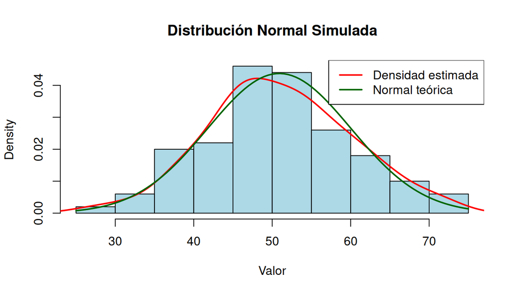

```r
# Histograma con curva de densidad
hist(datos, breaks = 15, probability = TRUE,
     col = "lightblue", main = "Distribución Normal Simulada",
     xlab = "Valor")

# Añadir curva de densidad estimada
lines(density(datos), col = "red", lwd = 2)

# Añadir curva teórica normal
curve(dnorm(x, mean = mean(datos), sd = sd(datos)),
      col = "darkgreen", lwd = 2, add = TRUE)
legend("topright", legend = c("Densidad estimada", "Normal teórica"),
       col = c("red", "darkgreen"), lwd = 2)
```